# Homework #3

Alec Meyer

9/20/2020

```r
data(tips, package="reshape2")
library(ggplot2)
```

Question 1

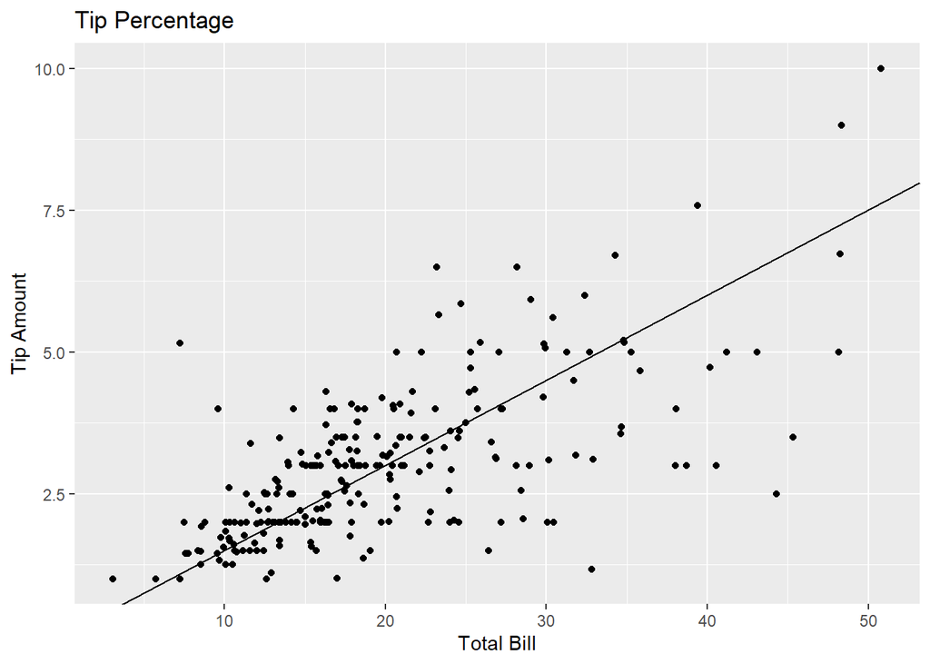

```r
p <- ggplot(data = tips, aes(x = total_bill, y = tip)) + geom_point()
p + geom_abline(intercept = 0, slope = 0.15) +
    ggtitle("Tip Percentage") +
    xlab("Total Bill") +
    ylab("Tip Amount")
```

This graph represents the relationship between total bill and tip amount. On average a customer tips anywhere between 15% to 20%. The line plotted is at 15% and we can see that there is a general trend around 15% possibly even slightly higher than 15%. Any point above the plotted line segment will be a tip above 15% and any point below the segment will be a tip below 15%.

Question 2  
There are two anomalies in this graph that stuck out to me. First of all, it appears that a higher total_bill results, on average, to a lower tip. In the graph shows bellow we can see that a majority of tips(points on the graph) are bellow the 15% line.

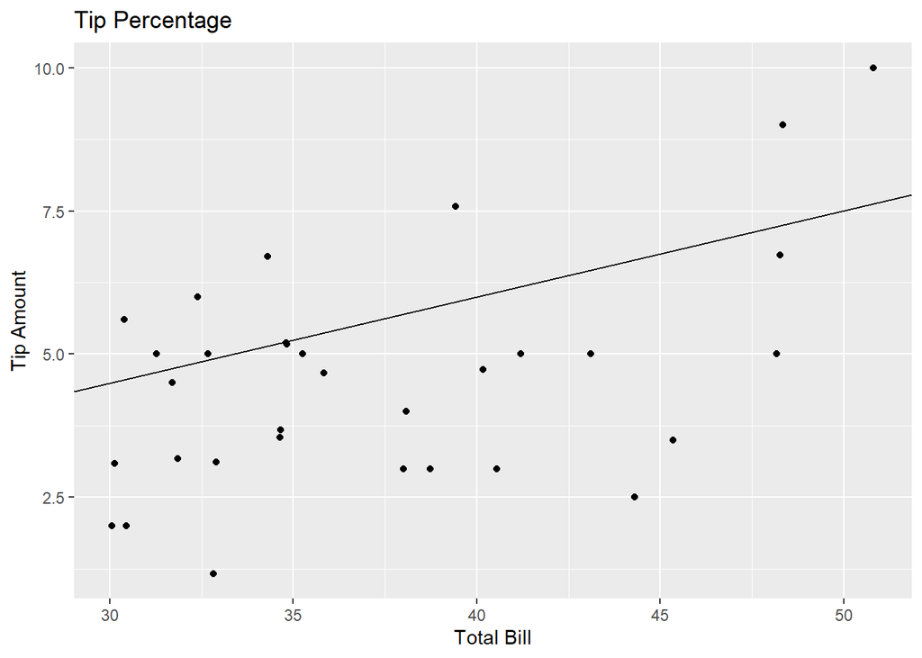

```r
tips2 <- tips[tips$total_bill > 30, ]
p <- ggplot(data = tips2, aes(x = total_bill, y = tip)) + geom_point()
p + geom_abline(intercept = 0, slope = 0.15) +
    ggtitle("Tip Percentage") +
    xlab("Total Bill") +
    ylab("Tip Amount")
```

This calculation shows the percentage of tips over 15% at a $30+ total bill.

```r
percent <- tips2$tip / tips2$total_bill
greater <- sum(percent >= 0.15)
greater / length(percent)
```

```
## [1] 0.25
```

As we can see, Only 25% of tips with a total bill greater than $30 are at least 15%.

```r
percent <- tips$tip / tips$total_bill
greater <- sum(percent >= 0.15)
greater / length(percent)
```

```
## [1] 0.557377
```

The above calculation shows that about 56% of all tips were at least 15%. This is very interesting to see and begs the question, why do higher total bills on average result in a lower tip percentage?  
The second interesting aspect of this previous plot is a strange pattern noticed between total bills of $10 to $17.

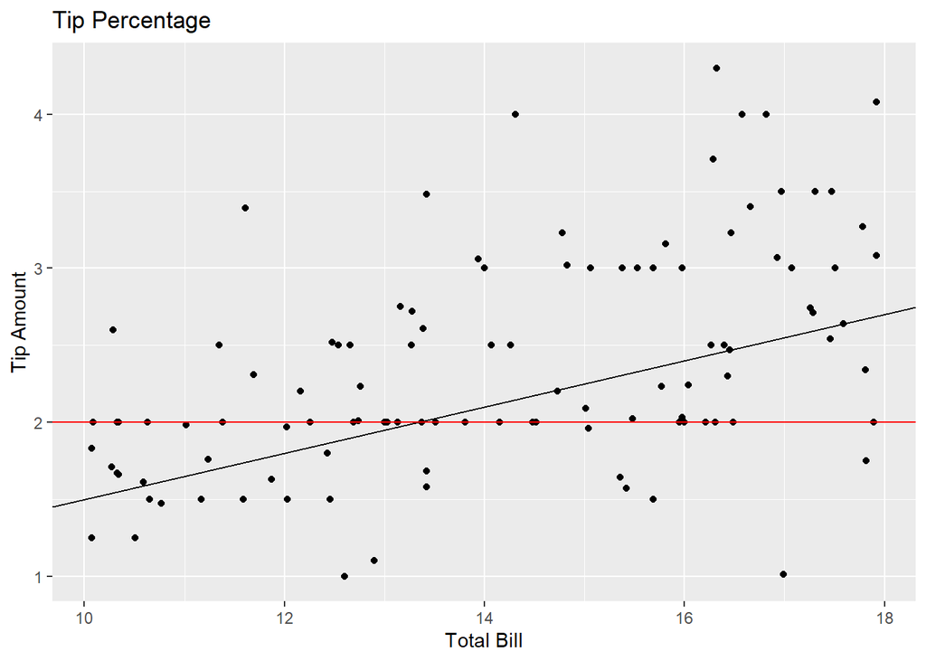

```r
tips3 <- tips[tips$total_bill >= 10 & tips$total_bill < 18, ]
p <- ggplot(data = tips3, aes(x = total_bill, y = tip)) + geom_point()
p + geom_abline(intercept = 0, slope = 0.15) +
    ggtitle("Tip Percentage") +
    xlab("Total Bill") +
    ylab("Tip Amount") +
    geom_abline(intercept = 2, slope = 0, color = 'red')
```

As you can see there are over 20 tips at just around the $2 mark spanning from $10 to $17.  
Question 3

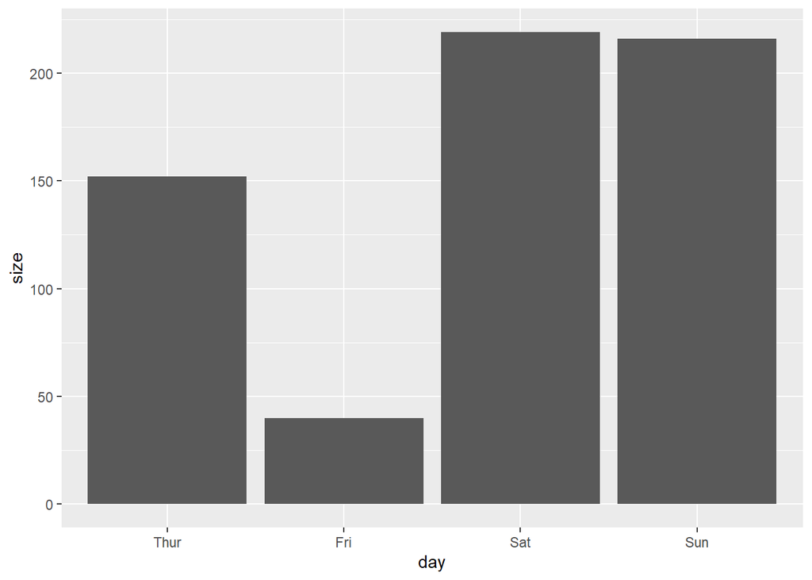

```r
tips$day <- factor(tips$day,levels = c("Thur", "Fri", "Sat", "Sun"))
ggplot(tips, aes(x = day, y = size)) +
  geom_bar(stat="identity")
```

Based off of the bar graph above it it surprising to see that Fridays are the days with the least amount of people. It is also interesting to see how low attendance is on Thursdays. Question 4

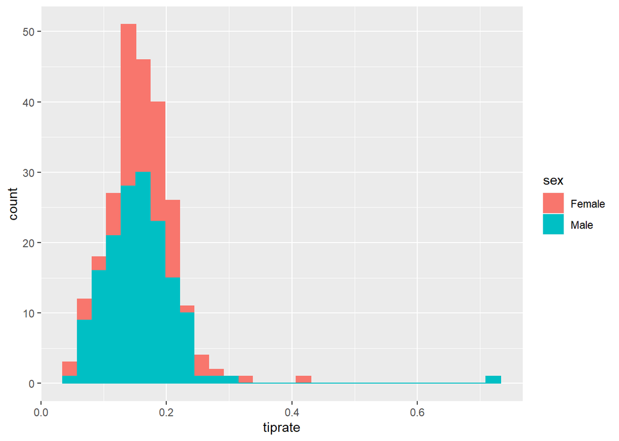

```r
tips$tiprate <- tips$tip / tips$total_bill
ggplot(tips, aes(x = tiprate, color = sex, fill = sex)) +
  geom_histogram()
```

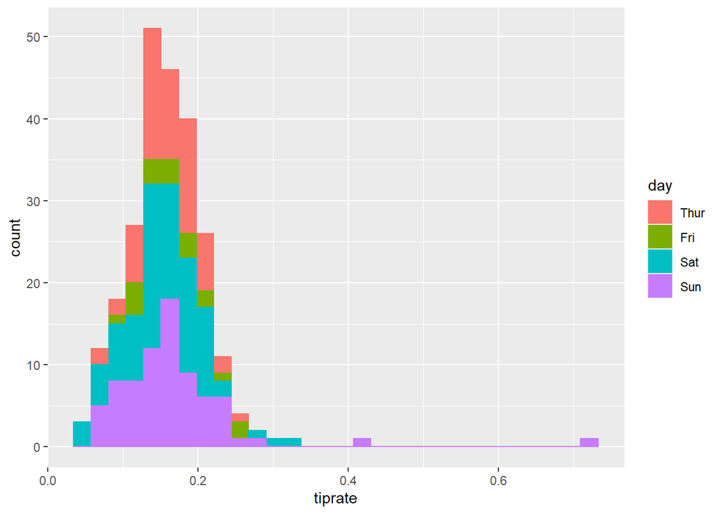

```r
ggplot(tips, aes(x = tiprate, color = day, fill = day)) +
  geom_histogram()
```

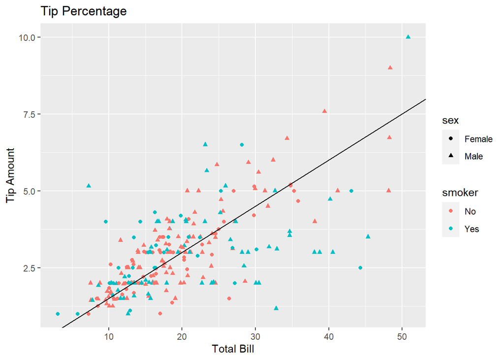

```r
p <- ggplot(data = tips, aes(x = total_bill, y = tip, color = smoker, shape = sex)) + geom_point()
p + geom_abline(intercept = 0, slope = 0.15) +
    ggtitle("Tip Percentage") +
    xlab("Total Bill") +
    ylab("Tip Amount")
```

This visualization shows the variables, tip, total_bill, sex, and smoker. It appears that a lot of female smokers do not tip close to 15% if their bill is above around $20. If the bill is below that then the female smokers seem to tip almost always over 15%. In general though it does not seem to affect the tip whether you have a smoker/non-smoker or really if they are male or female.  
Question 7

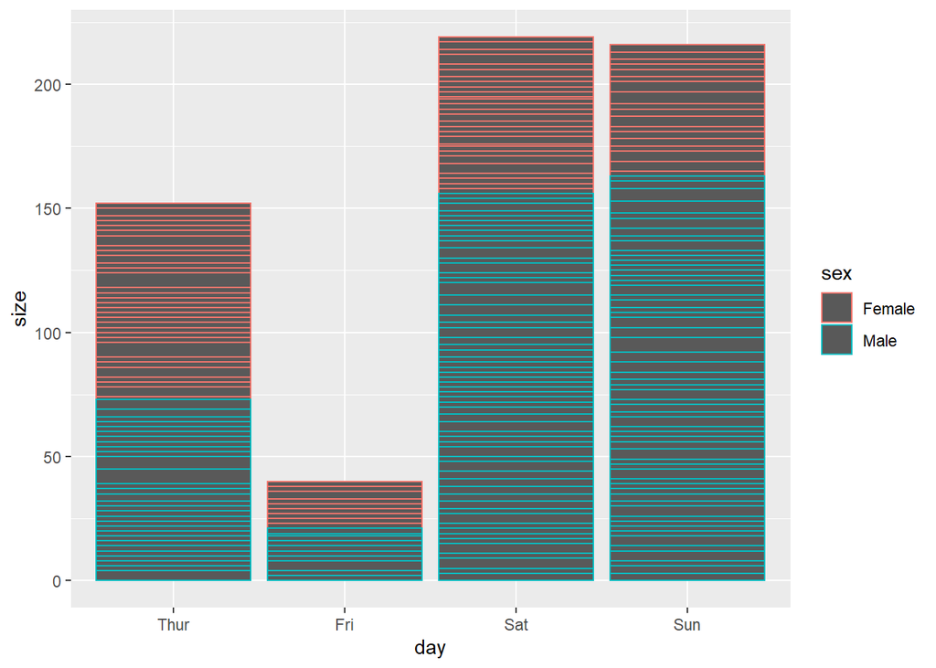

```r
ggplot(tips, aes(x = day, y = size, color = sex)) +
  geom_bar(stat="identity")
```